# Reproducible research project 1

Michael Liu

August 14, 2017

## Loading and preprocessing the data

Loading the data

```r
library(ggplot2)
activity <- read.csv("activity.csv")
```

Processing the data

```r
## Convert to date
activity$date <- as.Date(activity$date)
```

## What is mean total number of steps taken per day?

1. Calculate the total number of steps taken per day:

```r
Totalperday <- aggregate(steps ~ date, activity, sum)
print(Totalperday)
```

```
##          date steps
## 1  2012-10-02   126
## 2  2012-10-03 11352
## 3  2012-10-04 12116
## 4  2012-10-05 13294
## 5  2012-10-06 15420
## 6  2012-10-07 11015
## 7  2012-10-09 12811
## 8  2012-10-10  9900
## 9  2012-10-11 10304
## 10 2012-10-12 17382
## 11 2012-10-13 12426
## 12 2012-10-14 15098
## 13 2012-10-15 10139
## 14 2012-10-16 15084
```

[output cut: 39 more lines]

2. Make a histogram of the total number of steps taken each day

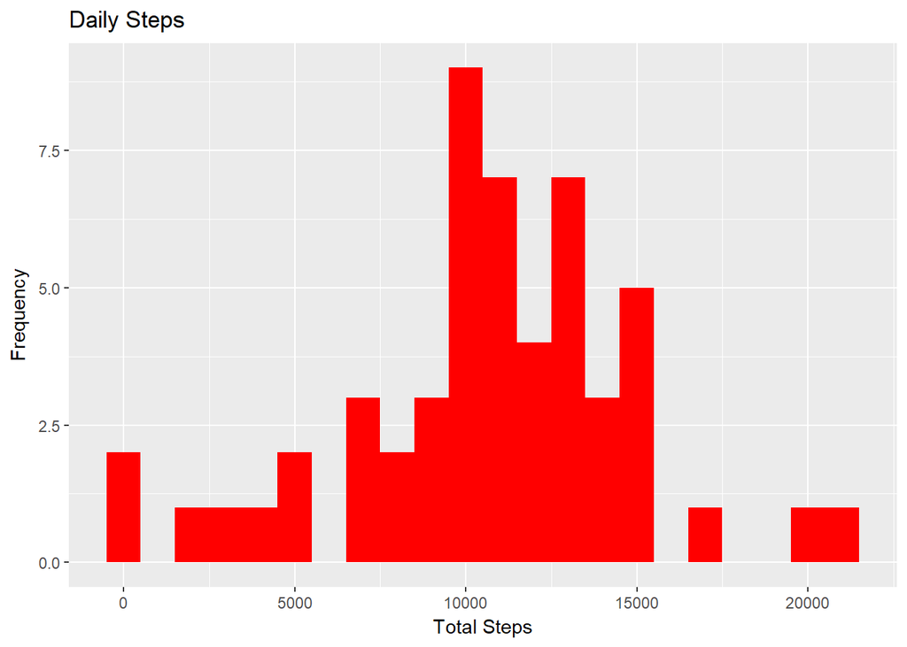

```r
ggplot(Totalperday, aes(x = steps)) +
      geom_histogram(fill = "red", binwidth = 1000) +
      labs(title = "Daily Steps", x = "Total Steps", y = "Frequency")
```

```r
Mean_Steps <- mean(Totalperday$steps, na.rm = TRUE)
Median_Steps <- median(Totalperday$steps, na.rm = TRUE)
```

## What is the average daily activity pattern?

1. Make a time series plot (i.e. type=“l”) of the 5-minute interval (x-axis) and the average number of steps taken, averaged across all days (y-axis).

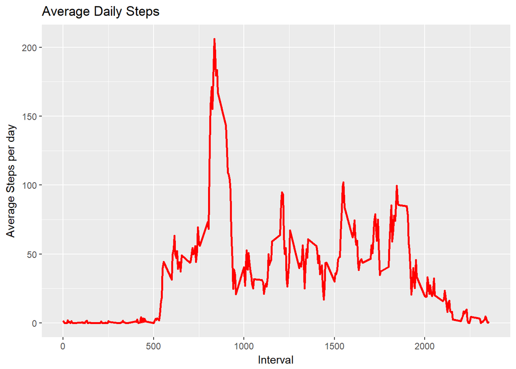

```r
## Remove NA values from the dataset
activity_tidy <- activity[!is.na(activity$steps), ]

## Create average number of steps per interval
library(plyr)
Steps_Interval <- ddply(activity_tidy, .(interval), summarize, Avg = mean(steps))

## Create line plot of average number of steps per interval
p <- ggplot(Steps_Interval, aes(x = interval, y = Avg))
p + geom_line(color = "red", size = 1) + labs(title = "Average Daily Steps", x = "Interval", y = "Average Steps per day")
```

2. Which 5-minute interval, on average across all the days in the dataset, contains the maximum number of steps.

```r
max_interval <- Steps_Interval[which.max(Steps_Interval$Avg), 1]
```

The 835th interval contains the maximum average steps.

## Imputing missing values

1. Calculate and report the total number of missing values in the dataset (i.e. the total number of rows with NAs)

```r
totalNA <- sum(!complete.cases(activity))
```

There are 2304 number of rows containing missing values.

2.Impute missing values by filling the mean for that interval 3. Create a new dataset that is equal to the original dataset but with the missing data filled in.

```r
imputed_data <- transform(activity, steps = ifelse(is.na(activity$steps), Steps_Interval$Avg[match(activity$interval, Steps_Interval$interval)], activity$steps))
```

```r
## Calculate and plot the imputed dataset and original dataset to show difference
Totalperday_i <- aggregate(steps ~ date, imputed_data, sum)
print(Totalperday_i)
```

```
##          date    steps
## 1  2012-10-01 10766.19
## 2  2012-10-02   126.00
## 3  2012-10-03 11352.00
## 4  2012-10-04 12116.00
## 5  2012-10-05 13294.00
## 6  2012-10-06 15420.00
## 7  2012-10-07 11015.00
## 8  2012-10-08 10766.19
## 9  2012-10-09 12811.00
## 10 2012-10-10  9900.00
## 11 2012-10-11 10304.00
## 12 2012-10-12 17382.00
## 13 2012-10-13 12426.00
## 14 2012-10-14 15098.00
```

[output cut: 47 more lines]

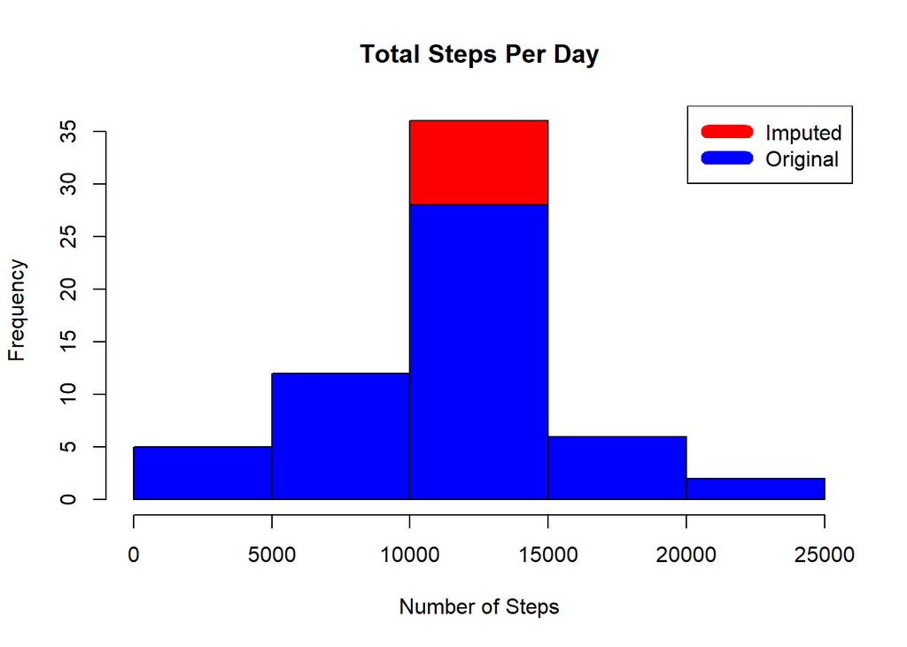

```r
hist(Totalperday_i$steps, main = paste("Total Steps Per Day"), col = "red", xlab = "Number of Steps", ylab = "Frequency")
hist(Totalperday$steps, col = "blue", add = TRUE)
legend("topright", c("Imputed", "Original"), col = c("red", "blue"), lwd = 10)
```

```r
## Calculate new mean and median for imputed dataset
Mean_Steps_i <- mean(Totalperday_i$steps)
Median_Steps_i <- median(Totalperday_i$steps)

## Calculate the difference
mean_diff <- Mean_Steps_i - Mean_Steps
median_diff <- Median_Steps_i - Median_Steps
total_diff <- sum(Totalperday_i$steps) - sum(Totalperday$steps)
```

## Are there differences in activity patterns between weekdays and weekends?

1. Create a new factor variable in the dataset with two levels - “weekday” and “weekend” indicating whether a given data is a weekday or weekend day.

```r
## Create a new factor variable indicating weekday or weekend in imputed dataset
Weekdays <- c("Monday", "Tuesday", "Wednesday", "Thursday", "Friday")
imputed_data$daytype <- as.factor(ifelse(weekdays(Totalperday_i$date) %in% Weekdays, "Weekday", "Weekend"))
```

2. Make a panel plot containing a time series plot of the 5-minute interval (x-axis) and the average number of steps taken, averaged across all weekday days or weekend days (y-axis).

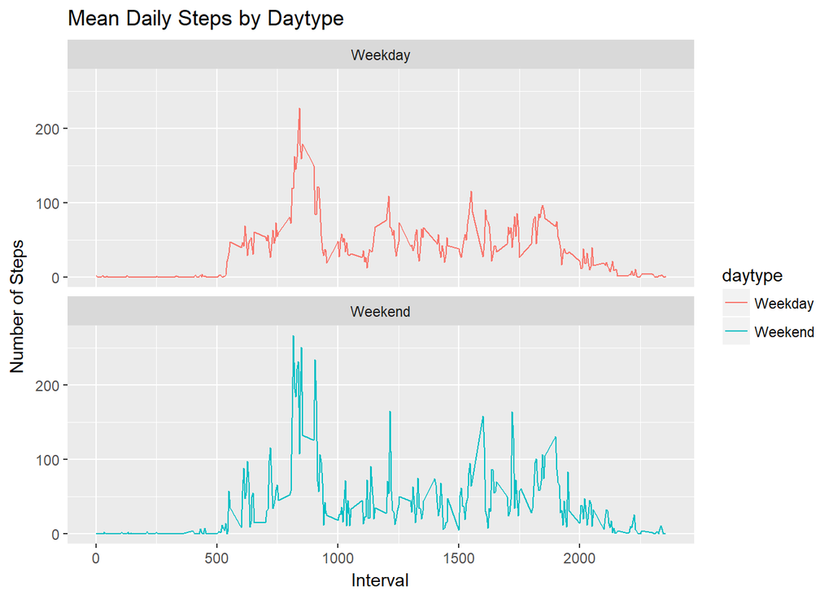

```r
Steps_Interval_i <- ddply(imputed_data, .(interval, daytype), summarize, Avg = mean(steps))

f <- ggplot(Steps_Interval_i, aes(x = interval, y = Avg, color = daytype)) + geom_line() + labs(title = "Mean Daily Steps by Daytype", x = "Interval", y = "Number of Steps") + facet_wrap(~daytype, ncol = 1, nrow = 2)
print(f)
```

Done